# **Introduction**

Healthcare is an important aspect of any society and government. In any success measurement of a nation, the quality of healthcare should be included. This study aims to examine the effectiveness of healthcare systems around the world through the specific lense of the impact of healthcare expenditure on citizens' life expectancy.

# **Hypothesis**

*My hypothesis prior to any data analysis is as follows:*

An increased amount of spending on healthcare in a country or region will increase citizens' life expectancy.

# **Method & Sources**

### Data Obtained From:

- 30-70cancerChdEtc.csv - Kaggle
- hlcosts.csv - World Health Organization
- data.xml - World Health Organization

### Method:

Using the data sources mentioned above, I first cleaned the data by mostly removing unnecessary columns, renaming any columns as necessary, and creating the regions (and regions2) dictionaries that I would use in code snippets throughout each analysis subsection. I created four analysis subsections: Averages, Trends Over Time, Correlation Coefficients, and Normal Curve Comparison. Within these subsections, I included healthcare cost analysis sections and life expectancy analysis sections as I thought were applicable.

# **Disclaimer: Study Shortcomings and Issues**

At present, this study has numerous shortcomings. First, the variables used to define the quality of healthcare are limited to only financial factors. A more inclusive study would focus on other variables, such as number of hospitals by population, medical equipment availability, patient wait times, insurance utilization (if applicable), and so forth. Another issue that presents itself is the sample size that is used. Only 5 countries were selected per region (Europe, Middle East, Asia, South America, North America, and Australia). Furthermore, regions North America and Australia only have one country in them (US and Australia, respectively). Additionally, the 5 countries in each region were not selected randomly, which could promote bias in the study's findings. Finally, some time-based measurements are not kept consistent between different data sources. Data source 30-70cancerChdEtc.csv examines year ranges from 2000 - 2016, while data source hlcosts.csv examines year ranges from 2002 - 2011 and data source data.xml examines year ranges from 2000 - 2019. This might cause some inconsistencies. On this note, date ranges included in this study are not the most up-to-date.

# **Data Sources, Parsing, and Cleaning**

```python
import pandas as pd
import matplotlib.pyplot as plt
import numpy as np
import scipy.stats as stats
import xml.etree.ElementTree as ET

# PROBABILITY OF DEATH FROM DISEASE BY COUNTRY CSV:
data = pd.read_csv('30-70cancerChdEtc.csv')

# HEALTH CARE COSTS BY COUNTRY CSV:
costdata = pd.read_csv('hlcosts.csv')

# LIFE EXPECTANCY BY COUNTRY XML:
tree = ET.parse('data.xml') #parsing
root = tree.getroot()
```

## **Data Cleaning**

### 30-70cancerChdEtc.csv File Cleaning:

```python
# Remove unnecessary columns
data = data.drop(columns=['Indicator'])

# Handle missing values (drop rows with missing values)
data = data.dropna()

# Rename columns
data = data.rename(columns={'Period': 'Year', 'Dim1': 'Sex', 'First Tooltip' : 'Death Probability'})

# Create a list of sample countries to examine:
countries = ['Denmark', 'Estonia', 'Italy', 'United Kingdom of Great Britain and Northern Ireland',
             'Portugal', 'Chile', 'Costa Rica', 'Colombia', 'Mexico', 'Argentina', 'China',
             'Democratic People\'s Republic of Korea', 'Japan', 'India', 'Indonesia', 'Israel',
             'Kazakhstan', 'Afghanistan', 'Saudi Arabia', 'Qatar', 'Kenya', 'Libya', 'Egypt',
             'Niger', 'Morocco', 'United States of America', 'Australia']

# Filter data for the sample countries
c_filtered_data = data[data['Location'].isin(countries)]

# Define regions and countries
regions = {
    'Europe': ['Denmark', 'Estonia', 'Italy', 'United Kingdom of Great Britain and Northern Ireland', 'Portugal'],
    'South America': ['Chile', 'Costa Rica', 'Colombia', 'Mexico', 'Argentina'],
    'Asia': ['China', 'Democratic People\'s Republic of Korea', 'Japan', 'India', 'Indonesia'],
    'Middle East': ['Israel', 'Kazakhstan', 'Afghanistan', 'Saudi Arabia', 'Qatar'],
    'Africa': ['Kenya', 'Libya', 'Egypt', 'Niger', 'Morocco'],
    'North America': ['United States of America'],
    'Australia': ['Australia']
}
```

### hlcosts.csv File Cleaning:

```python
# Define regions and countries
regions2 = {
    'Europe': ['Denmark', 'Estonia', 'Italy', 'United Kingdom of Great Britain and Northern Ireland', 'Portugal'],
    'South America': ['Chile', 'Costa Rica', 'Colombia', 'Mexico', 'Argentina'],
    'Asia': ['China', 'Republic of Korea', 'Japan', 'India', 'Indonesia'],
    'Middle East': ['Israel', 'Kazakhstan', 'Afghanistan', 'Saudi Arabia', 'Qatar'],
    'Africa': ['Kenya', 'Libya', 'Egypt', 'Niger', 'Morocco'],
    'North America': ['United States of America'],
    'Australia': ['Australia']
}
```

A new dictionary is defined for this file because of some differences in country names.

# **Data Analysis**

## Averages

### *Life Expectancy*

This code snippet takes a look at the average probability of death due to cardiovascular disease, diabetes, or chronic respiratory disease by country for citizens between the ages of 30 and 70. I didn't start with regions in this first average because I wanted to show each country on its own first. However, from this point on, I only use regions instead of countries.

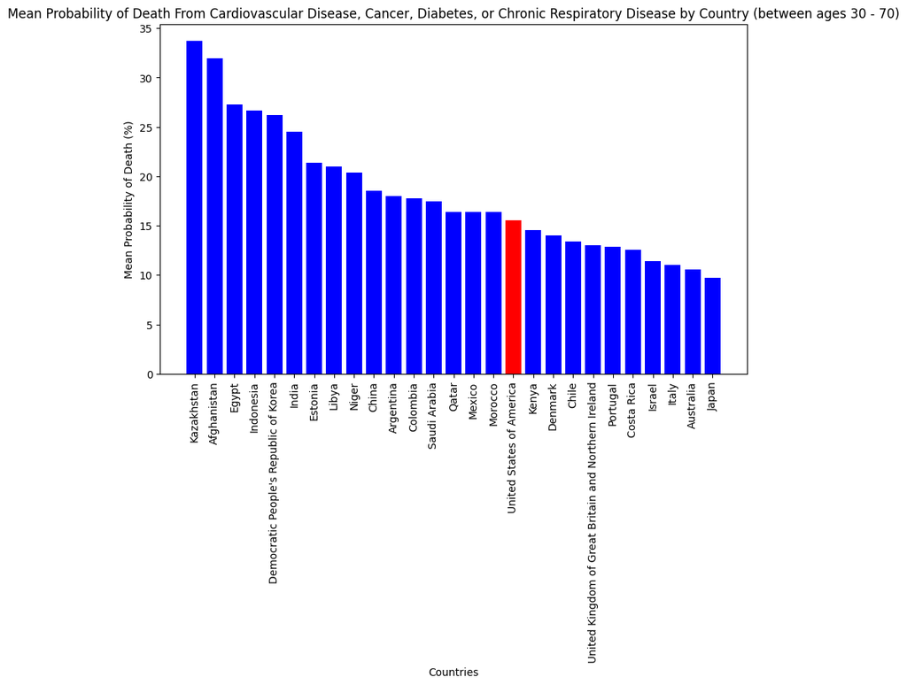

```python
# Calculate the mean probability for each country
mean_probabilities = c_filtered_data.groupby('Location')['Death Probability'].mean()

# Sort the mean probabilities in descending order
sorted_mean_probabilities = mean_probabilities.sort_values(ascending=False)

# Create the chart dimensions
plt.figure(figsize=(10, 6))

# Iterate over the countries and assign different colors based on the country's name
for country, mean_probability in zip(sorted_mean_probabilities.index, sorted_mean_probabilities.values):
    if country == 'United States of America':
        plt.bar(country, mean_probability, color='red')
    else:
        plt.bar(country, mean_probability, color='blue')

plt.xlabel('Countries')
plt.ylabel('Mean Probability of Death (%)')
plt.title('Mean Probability of Death From Cardiovascular Disease, Cancer, Diabetes, or Chronic Respiratory Disease by Country (between ages 30 - 70)')
plt.xticks(rotation=90)
plt.show()
```

In this case, from the generated bar chart, we can see the US (colored in red) is on the mid- to lower-end of the graph with an average probability of death due to these diseases in between 15% - 20% probability. The significance of this chart is that we can see the countries that have the highest probability of death by disease, which could help us determine which countries have better healthcare.

### *WHO Life Expectancy Data*

The code snippet below shows the average life expectancy from birth for each region. Averages are calculated based on only the years 2000, 2010, and 2015 (only the years 2000, 2010, 2015, and 2019 were available in the data.xml file) by region in an attempt to maintain consistency with the years from other data sources.

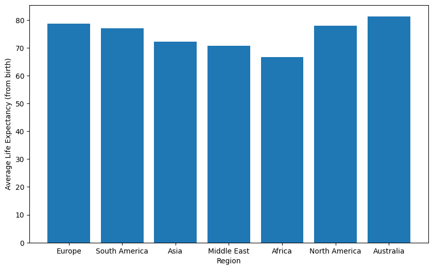

```python
# Loop through all the facts and extract relevant data by xml tags
data = []
for fact in root.iter('Fact'):
    gho = fact.find('GHO').text
    sex = fact.find('SEX').text
    if gho == 'Life expectancy at birth (years)' and sex == 'Both sexes':  #only want these because gho tag in xml file also includes other kinds of life expectancies and individually male/female
        country = fact.find('COUNTRY').text
        year = fact.find('YEAR').text
        value = float(fact.find('Display').text)
        data.append((country, year, value))

# Calculate averages by region
region_averages = {region: [] for region in regions}
for country, year, value in data:
    for region, countries in regions.items():
        if country in countries and year in ['2000', '2010', '2015']:   #only want these years because 2019 was included in this dataset too, but want it to match with other used datasets
            region_averages[region].append(value) #add to region_averages dict
averages = [sum(region_averages[region]) / len(region_averages[region]) for region in regions] #based on vals in region_averages dict, find averages

# Adjust chart size
fig = plt.gcf()
fig.set_size_inches(10, 6)

# Plot the bar chart
plt.bar(range(len(regions)), averages)
plt.xticks(range(len(regions)), regions.keys())
plt.ylabel('Average Life Expectancy (from birth)')
plt.xlabel('Region')
plt.show()
```

This significance of this, based on the outputted graph, shows that Australia, North America, and Europe have highest average life expectancies from birth - hovering at around 80 years old - while Africa and the Middle East have the lowest, hovering at around 70 years old.

## Trends Over Time

### *Life Expectancy*

Here we can see the average probability of death due to the listed diseases by region overtime (between ages 30 - 70).

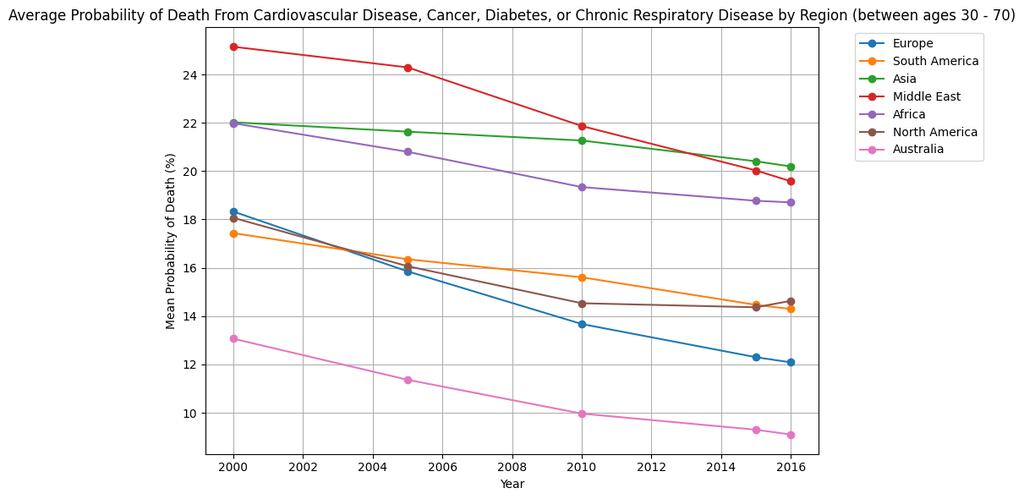

```python
# Add a 'Region' column to the data
def get_region(country):
    for region, countries in regions.items():
        if country in countries:
            return region
    return None

c_filtered_data['Region'] = c_filtered_data['Location'].apply(get_region)

# Calculate the mean probability of death by region and year
region_year_data = c_filtered_data.groupby(['Region', 'Year'])['Death Probability'].mean().reset_index()

# Create the line chart
plt.figure(figsize=(10, 6))

# Plot each region's data
for region in regions.keys():
    region_data = region_year_data[region_year_data['Region'] == region]
    plt.plot(region_data['Year'], region_data['Death Probability'], marker='o', label=region)

plt.xlabel('Year')
plt.ylabel('Mean Probability of Death (%)')
plt.title('Average Probability of Death From Cardiovascular Disease, Cancer, Diabetes, or Chronic Respiratory Disease by Region (between ages 30 - 70)')
plt.legend(bbox_to_anchor=(1.05, 1), loc='upper left')
plt.grid(True)
plt.tight_layout()
plt.show()
```

### *Healthcare Costs*

**OOP Per Capita in US$ (millions)**

This coded out graph will show the out-of-pocket expense per capita in US dollars (millions) for citizens' of each region. All currency is converted to and expressed in US dollars (millions) to maintain consistency and equal point of reference.

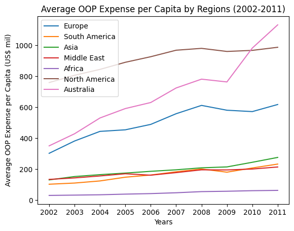

```python
# Filter the dataframe for OOPS indicator
hlcosts_oops = costdata[costdata['Indicators'] == 'Out-of-Pocket Expenditure (OOPS) per Capita in US$']

# Calculate the mean values for each region and year
region_means = {}
years = [str(year) for year in range(2002, 2012)]
for region, countries in regions2.items():
    region_data = hlcosts_oops[hlcosts_oops['Countries'].isin(countries)].copy()
    for year in years:
        region_data[year] = region_data[year].str.replace(',', '').astype(float)
    mean_values = region_data.loc[:, years].mean(axis=0).values
    region_means[region] = mean_values

# Create the chart
x = np.arange(len(years))

fig, ax = plt.subplots()
for region, means in region_means.items():
    ax.plot(x, means, label=region)

ax.set_xticks(x)
ax.set_xticklabels(years)
ax.set_xlabel('Years')
ax.set_ylabel('Average OOP Expense per Capita (US$ mil)')
ax.set_title('Average OOP Expense per Capita by Regions (2002-2011)')
ax.legend()

plt.show()
```

**Domestic General Government Expenditure as % Current Health Expenditure (US$ millions)**

This coded out graph will show the domestic general government expenditure in US dollars (millions) as a percent of current health expenditure for citizens' of each region. All currency is converted to and expressed in US dollars (millions) to maintain consistency and equal point of reference.

[figure not shown]

```python
# Filter the dataframe for OOPS indicator
hlcosts_dgve = costdata[costdata['Indicators'] == 'Domestic General Government Health Expenditure (GGHE-D) as % Current Health Expenditure (CHE)']

# Calculate the mean values for each region and year
region_means_g = {}
years = [str(year) for year in range(2002, 2012)]
for region, countries in regions2.items():
    region_data_g = hlcosts_dgve[hlcosts_dgve['Countries'].isin(countries)].copy()
    for year in years:
        region_data_g[year] = region_data_g[year].str.replace(',', '').astype(float)
    mean_values_g = region_data_g.loc[:, years].mean(axis=0).values
    region_means_g[region] = mean_values_g

# Create the chart
x = np.arange(len(years))

fig, ax = plt.subplots()
for region, means in region_means.items():
    ax.plot(x, means, label=region)

ax.set_xticks(x)
ax.set_xticklabels(years)
ax.set_xlabel('Years')
ax.set_ylabel('Average Gov Health Expenditure %')
ax.set_title('Average Domestic General Gov Health Expenditure as % Current Health Expenditure (2002-2011)')
ax.legend()

plt.show()
```

## Correlation Coefficients

### Correlation Between Average OOP Expenses and Life Expectancy (from birth) from the years 2000 - 2015

```python
# Get the mean OOP expenses and life expectancies as lists
oop_expenses = []
life_expectancies = []

# Add values to oop_expenses list based on region
for region in regions2:
    oop_expenses.append(region_means[region].mean())

# Add values to life_expectancies list based on region
for region in regions:
    if region in region_averages:
        life_expectancies.append(sum(region_averages[region]) / len(region_averages[region]))

# Calculate the Pearson correlation coefficient and p-value
corr, pval = stats.pearsonr(oop_expenses, life_expectancies)

print('Pearson correlation coefficient:', corr)
print('p-value:', pval)
```

```
Pearson correlation coefficient: 0.7710537867290918
p-value: 0.042396657248920576
```

Based on the relatively high Pearson correlation coefficient, it can be said that there is a fairly strong positive correlation between increased out-of-pocket expenditures and increased life expectancy. However, correlation does not equal causation, so it could not be claimed that if citizens have more out-of-pocket expenses that their life expectancy would increase. This assumption is further supported by the p-value of 0.042, which indicates that there is moderate evidence against the null hypothesis, which just means that there is only moderate evidence against the idea that there is no effect of increased out-of-pocket spending on life expectancy.

### Correlation Between Average Gov Healthcare Spending and Life Expectancy (from birth) from the years 2000 - 2015

```python
# Get the mean Gov Healthcare Spending and Life Expectancies as lists
dgve_expenses = []
life_expectancies = []

# Add values to dgve_expenses list based on region
for region in regions2:
    dgve_expenses.append(region_means_g[region].mean())

# Add values to life_expectancies list based on region
for region in regions:
    if region in region_averages:
        life_expectancies.append(sum(region_averages[region]) / len(region_averages[region]))

# Calculate the Pearson correlation coefficient and p-value
corr, pval = stats.pearsonr(dgve_expenses, life_expectancies)

print('Pearson correlation coefficient:', corr)
print('p-value:', pval)
```

```
Pearson correlation coefficient: 0.7613398517459196
p-value: 0.04677272008002264
```

These results are fairly similar to the results when testing the relationship between oop and life expectancy. In this case, it can be said that there is a fairly strong positive correlation between increased government healthcare spending and increased life expectancy. Again, however, this cannot be taken to mean that correlation is equal to causation. It cannot be said with definitiveness that an increase in government spending will lead to increased life expectancy. This is, again, supported by a moderate p-value of 0.047.

## Normal Curve Comparison

### *Life Expectancy*

This code will show the Probability of Death Due to Cardiovascular Disease, Cancer, Diabetes, or Chronic Respiratory Disease (between ages 30-70) as a bell curve and where each region falls on that bell curve.

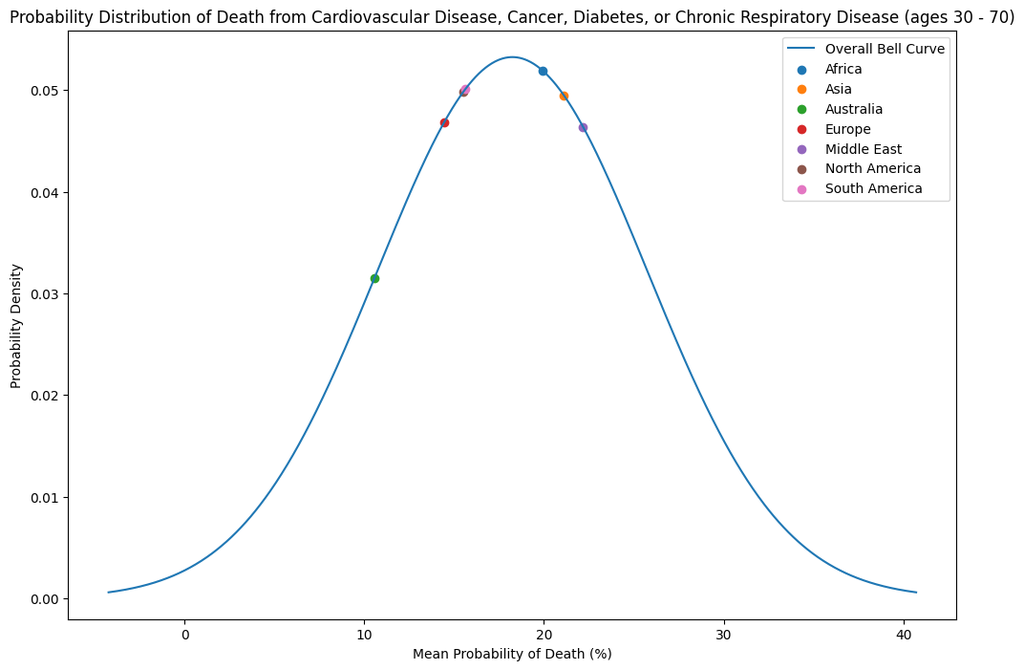

```python
# Calculate the overall mean and standard deviation of death probabilities
overall_mean = c_filtered_data['Death Probability'].mean()
overall_std_dev = c_filtered_data['Death Probability'].std()

# Standardize death probabilities (optional)
# c_filtered_data['Death Probability'] = (c_filtered_data['Death Probability'] - overall_mean) / overall_std_dev

# Plotting the bell curve for all regions
plt.figure(figsize=(12, 8))

# Create an array for x-axis (probability values)
x = np.linspace(overall_mean - 3 * overall_std_dev, overall_mean + 3 * overall_std_dev, 1000)

# Plot the bell curve
y = stats.norm.pdf(x, overall_mean, overall_std_dev)
plt.plot(x, y, label='Overall Bell Curve')

# Plot mean probabilities for each region as dots on the bell curve
for region, mean_prob in c_filtered_data.groupby('Region')['Death Probability'].mean().items():
    plt.scatter(mean_prob, stats.norm.pdf(mean_prob, overall_mean, overall_std_dev), label=region, marker='o')

plt.xlabel('Mean Probability of Death (%)')
plt.ylabel('Probability Density')
plt.title('Probability Distribution of Death from Cardiovascular Disease, Cancer, Diabetes, or Chronic Respiratory Disease (ages 30 - 70)')
plt.legend()
plt.show()
```

### *Healthcare Costs*

This code will show the Domestic General Government Health Expenditure (GGHE-D) as % Current Health Expenditure as a bell curve and where each region falls on that bell curve.

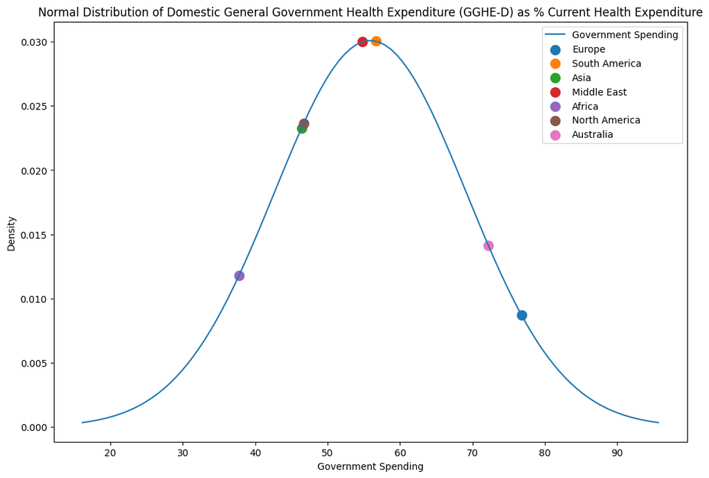

```python
# Get the mean and standard deviation of the government spending
mean_spending = np.mean(list(region_means_g.values()))
std_spending = np.std(list(region_means_g.values()))

# Create a plot
plt.figure(figsize=(12, 8))

# Create the normal distribution curve
x_values = np.linspace(mean_spending - 3 * std_spending, mean_spending + 3 * std_spending, 100)
y_values = stats.norm.pdf(x_values, mean_spending, std_spending)
plt.plot(x_values, y_values, label='Government Spending')

# Iterate over the regions, filter the data, calculate the mean government spending, and plot the position on the distribution
for region_name, region_spending in region_means_g.items():
    z_score = (np.mean(region_spending) - mean_spending) / std_spending
    plt.scatter(mean_spending + z_score * std_spending, stats.norm.pdf(mean_spending + z_score * std_spending, mean_spending, std_spending), s=100, label=region_name)

plt.xlabel('Government Spending')
plt.ylabel('Density')
plt.title('Normal Distribution of Domestic General Government Health Expenditure (GGHE-D) as % Current Health Expenditure')
plt.legend()
plt.show()
```

Based on this output, we can see that all the region values fall within at least 3 standard deviations of the mean. The mean amount of domestic government healthcare spending (in millions US$) as a percentage of current health expenditure is around 60%. We can see that Africa, Asia, and North America are to the left of the mean with lower amounts of government healthcare spending. Whereas, Australia and Europe are to the right of the mean with higher amounts of government healthcare spending. South America and the Middle East hover around the mean. When comparing this bell curve to the probability of death due to diseases bell curve, we see that some of the regions on the lower probability of death side of that curve (Australia and Europe) are on the higher government spending side of this bell curve. However, North America is an exception being on the lower probability of death side of that bell curve and being on the lower side of the government spending curve as well.

# **Conclusions**

While there are some general trends observed throughout this study that do support the initial hypothesis by indicating higher healthcare spending - whether it be government or citizen out of pocket spending - can lead to higher life expectancy and lower probability of death due to some diseases, it cannot be said for certain that higher healthcare spending usually leads to higher life expectancy. Other variables would have to be examined and the sample size would have to be increased in order to come to more definitive conclusions.